# Behavioral RP Recruiting: Apologies Survey Analysis

2024-01-31

# Task 1: Answer a Research Question

## (1) Do people care about getting a return apology after being the first to apologize?

We are testing to see whether there is a significant difference between the mean rated feeling when a participant is presented with two scenarios: (1) feelings_youalone: the participant apologizes without a return apology and (2) feelings_bothyoufirst: the participant apologizes and the opposing party apologizes after. We will be using a one-way ANOVA test to check for a significant difference between these two means.

$\mu_1$ = mean of feelings for “feelings_youalone” (the participant apologizes without a return apology)

$\mu_2$ = mean of feelings for “feelings_bothyoufirst” (the participant apologizes and the opposing party apologizes after)

Null hypothesis: $H_0$:$\mu_1 = \mu_2$

Alternate hypothesis: $H_1$: $\mu_1 \neq \mu_2$

```
##             Df Sum Sq Mean Sq F value   Pr(>F)
## scenario     1  15445   15445   87.38 7.89e-15 ***
## Residuals   88  15554     177
## ---
## Signif. codes:  0 '***' 0.001 '**' 0.01 '*' 0.05 '.' 0.1 ' ' 1
```

The one-way ANOVA test shows that there is a significant difference between the mean rated feeling in the two presented scenarios (p-value = 7.89*10<sup>-15</sup> < 0.05). This implies that people who apologize first feel significantly different about the situation when they receive a return apology and when they don’t.

```
##
##  Shapiro-Wilk normality test
##
## data:  residuals
## W = 0.97857, p-value = 0.1433
```

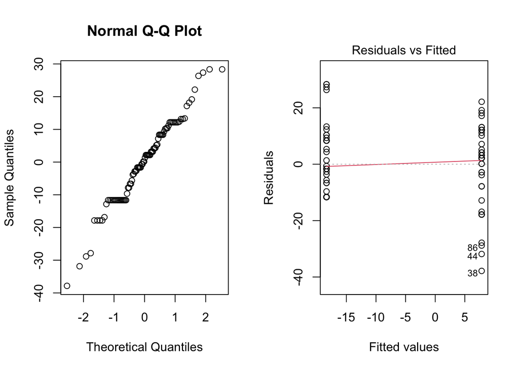

The normality and variance conditions of the model are met.

```
##   Tukey multiple comparisons of means
##     95% family-wise confidence level
##
## Fit: aov(formula = feelings ~ scenario, data = apology_data_youfirst)
##
## $scenario
##                                          diff       lwr       upr p adj
## feelings_youalone-feelings_bothyoufirst -26.2 -31.76997 -20.63003     0
```

We are 95% confident that the mean rated feeling of the participant when apologizing alone is between 31.77 and 20.63 points less than the mean rated feeling of the participant when apologizing first followed by the opposing party’s apology.

## (2) Does this vary as function of individual differences in “initiator type”?

We are testing to see whether there is a significant interaction effect between the initiator type and scenario on rated feeling. We will be be using a two-way ANOVA test to test for a significant difference between the means of each initiator type and scenario combination.

Alternate hypothesis: $H_1$: at least one $\mu_{i:j}$ $\neq$ $\mu_{i:j}$

```
##                         Df Sum Sq Mean Sq F value   Pr(>F)
## scenario                 1  15445   15445  95.845 1.53e-15 ***
## initiator_type           2   1890     945   5.864  0.00413 **
## scenario:initiator_type  2    128      64   0.398  0.67311
## Residuals               84  13536     161
## ---
## Signif. codes:  0 '***' 0.001 '**' 0.01 '*' 0.05 '.' 0.1 ' ' 1
```

From this two-way ANOVA test, we can see that although scenario and initiator type are both independently significant to the mean rated feeling, with p-values of 1.53*10<sup>^-15</sup> and 0.00413 respectively, they do not have a significant interaction (p-value = 0.67311). This implies that the effect of the scenario on rated feeling is consistent no matter what the self-declared initiator type was. This also implies that the effect of initiator type on rated feeling is consistent no matter what the scenario was. The relationship between scenario and initiator type does not significantly affect the rated feeling.

```
##                Df Sum Sq Mean Sq F value Pr(>F)
## initiator_type  2   1890   944.9   2.824 0.0648 .
## Residuals      87  29109   334.6
## ---
## Signif. codes:  0 '***' 0.001 '**' 0.01 '*' 0.05 '.' 0.1 ' ' 1
```

In order to test initiator_type’s significance to rated feeling more independently, we conducted an additional one-way ANOVA test. This produced a non-significant p-value of 0.0648. Due to the discrepancies in p-values (0.00413 from the two-way ANOVA test vs 0,0648 from the one-way ANOVA test), we are hesitant to say that there is sufficient enough evidence to reject the main effect null hypothesis, which states that the mean rated feeling among initiator_types are equal.

```
##
##  Shapiro-Wilk normality test
##
## data:  residuals
## W = 0.99292, p-value = 0.9157
```

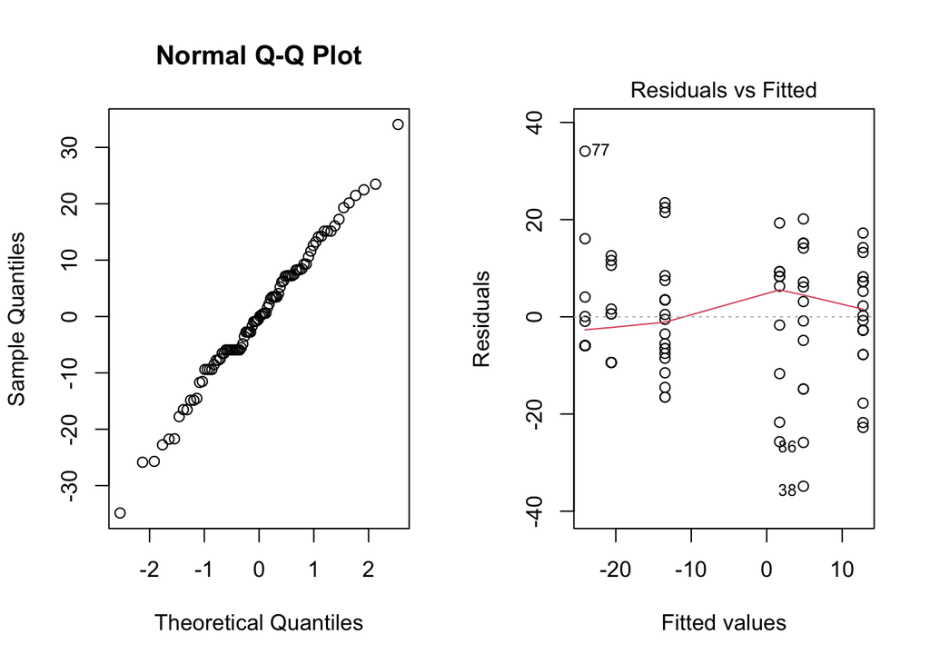

The normality and variance conditions of the model are met. We will not be conducting a Tukey Test since the interaction effect is non-significant.

## (3) IS a return apology simply viewed as a form of forgiveness?

We are testing to see whether there is a significant difference between the mean rated feeling when a participant is presented with two scenarios: (1) the participant apologizes and receives forgiveness and (2) the participant apologizes and the opposing party apologizes after. We will be using a one-way ANOVA test to check for a significant difference between these two means.

$\mu_1$ = mean of feeling for “feelings_youaloneforgive” (the participant apologizes and receives forgiveness)

$\mu_2$ = mean of feeling for “feelings_bothyoufirst” (the participant apologizes and the opposing party apologizes after)

Null hypothesis: $H_0$:$\mu_1 = \mu_2$

Alternate hypothesis: $H_1$: $\mu_1 \neq \mu_2$

```
##             Df Sum Sq Mean Sq F value   Pr(>F)
## scenario     1  10649   10649   47.04 9.25e-10 ***
## Residuals   88  19924     226
## ---
## Signif. codes:  0 '***' 0.001 '**' 0.01 '*' 0.05 '.' 0.1 ' ' 1
```

The one-way ANOVA test shows that there is a significant difference (p = 9.25*10<sup>-10</sup> < 0.05) between the mean rated feeling in the two presented scenarios. This implies that people who apologize first and receive forgiveness feel significantly different about the situation than when they receive a return apology.

```
##
##  Shapiro-Wilk normality test
##
## data:  residuals
## W = 0.97314, p-value = 0.05902
```

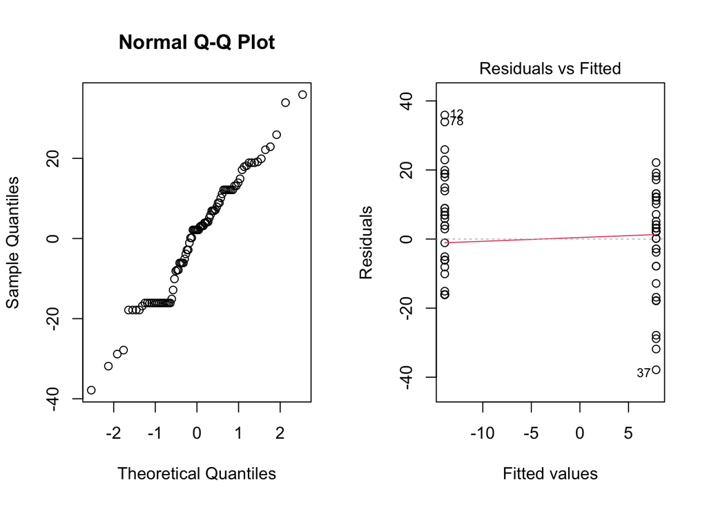

The normality and variance conditions of the model are met.

```
##   Tukey multiple comparisons of means
##     95% family-wise confidence level
##
## Fit: aov(formula = feelings ~ scenario, data = apology_data_return)
##
## $scenario
##                                                      diff      lwr       upr
## feelings_youaloneforgiven-feelings_bothyoufirst -21.75556 -28.0595 -15.45162
##                                                 p adj
## feelings_youaloneforgiven-feelings_bothyoufirst     0
```

# Task 2 - Conduct additional analyses

## (a) Produce a single bar graph that shows the average of the “feelings” variable for all six scenarios, in order of decreasing value. Include error bars (standard errors or confidence intervals). Label fully. Describe your observations in 1-2 sentences.

```
## avg_feelings
## -18.3555555555556 -14.3777777777778 -13.9111111111111 -5.53333333333333
##                 1                 1                 1                 1
##  7.84444444444444  17.4222222222222
##                 1                 1
```

```
##    feelings_boththemfirst     feelings_bothyoufirst          feelings_neither
##                  1.697440                  2.154384                  1.663418
##        feelings_themalone         feelings_youalone feelings_youaloneforgiven
##                  2.517133                  1.792846                  2.328311
```

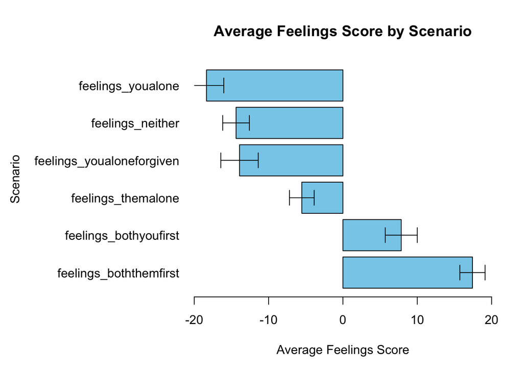

The mean ranked feeling is worse for scenarios in which the participant apologizes alone or there is no apology (feelings_youalone, feelings_youaloneforgiven, feelings_neither). People much prefer scenarios in which both parties end up apologizing rather than anyone apologizing alone, including the opposing party apologizing alone.

## (b) Conduct a one way ANOVA to determine if there are differences in feelings across the six scenarios. Then perform pairwise t-tests to compare “feelings_youalone” to the other five scenarios. Describe your conclusions in 1-2 sentences.

```
##              Df Sum Sq Mean Sq F value Pr(>F)
## scenario      5  45547    9109   48.08 <2e-16 ***
## Residuals   264  50017     189
## ---
## Signif. codes:  0 '***' 0.001 '**' 0.01 '*' 0.05 '.' 0.1 ' ' 1
```

```
##
##  Shapiro-Wilk normality test
##
## data:  residuals
## W = 0.9892, p-value = 0.04191
```

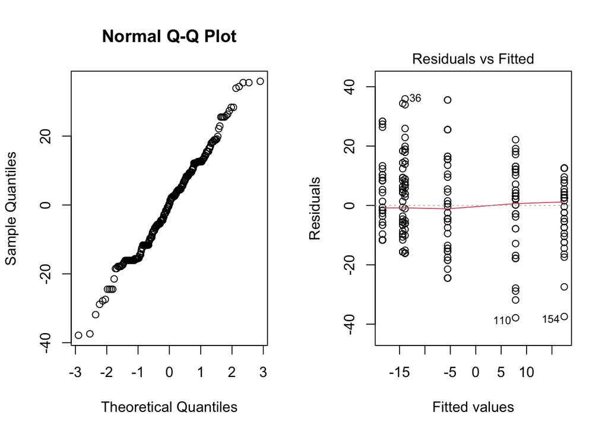

```
##   Tukey multiple comparisons of means
##     95% family-wise confidence level
##
## Fit: aov(formula = feelings ~ scenario, data = long_apology_data)
##
## $scenario
##                                                         diff         lwr
## feelings_bothyoufirst-feelings_boththemfirst      -9.5777778 -17.9081207
## feelings_neither-feelings_boththemfirst          -31.8000000 -40.1303429
## feelings_themalone-feelings_boththemfirst        -22.9555556 -31.2858984
## feelings_youalone-feelings_boththemfirst         -35.7777778 -44.1081207
## feelings_youaloneforgiven-feelings_boththemfirst -31.3333333 -39.6636762
## feelings_neither-feelings_bothyoufirst           -22.2222222 -30.5525651
## feelings_themalone-feelings_bothyoufirst         -13.3777778 -21.7081207
## feelings_youalone-feelings_bothyoufirst          -26.2000000 -34.5303429
## feelings_youaloneforgiven-feelings_bothyoufirst  -21.7555556 -30.0858984
## feelings_themalone-feelings_neither                8.8444444   0.5141016
## feelings_youalone-feelings_neither                -3.9777778 -12.3081207
## feelings_youaloneforgiven-feelings_neither         0.4666667  -7.8636762
## feelings_youalone-feelings_themalone             -12.8222222 -21.1525651
## feelings_youaloneforgiven-feelings_themalone      -8.3777778 -16.7081207
## feelings_youaloneforgiven-feelings_youalone        4.4444444  -3.8858984
##                                                          upr     p adj
## feelings_bothyoufirst-feelings_boththemfirst      -1.2474349 0.0138525
## feelings_neither-feelings_boththemfirst          -23.4696571 0.0000000
## feelings_themalone-feelings_boththemfirst        -14.6252127 0.0000000
## feelings_youalone-feelings_boththemfirst         -27.4474349 0.0000000
## feelings_youaloneforgiven-feelings_boththemfirst -23.0029905 0.0000000
## feelings_neither-feelings_bothyoufirst           -13.8918793 0.0000000
## feelings_themalone-feelings_bothyoufirst          -5.0474349 0.0000912
## feelings_youalone-feelings_bothyoufirst          -17.8696571 0.0000000
## feelings_youaloneforgiven-feelings_bothyoufirst  -13.4252127 0.0000000
## feelings_themalone-feelings_neither               17.1747873 0.0301870
## feelings_youalone-feelings_neither                 4.3525651 0.7444827
## feelings_youaloneforgiven-feelings_neither         8.7970095 0.9999849
## feelings_youalone-feelings_themalone              -4.4918793 0.0002088
## feelings_youaloneforgiven-feelings_themalone      -0.0474349 0.0477959
## feelings_youaloneforgiven-feelings_youalone       12.7747873 0.6441545
```

```
## feelings_boththemfirst  feelings_bothyoufirst       feelings_neither
##           1.026525e-26           5.600313e-16           1.000000e+00
##     feelings_themalone      feelings_youalone
##           2.175674e-04                     NA
```

## (c) Create a graph showing the proportion of people choosing each of the different options for the following variable: outcome_binary1. Conduct a test to determine if the proportion differences across the answers are significantly different from one another.

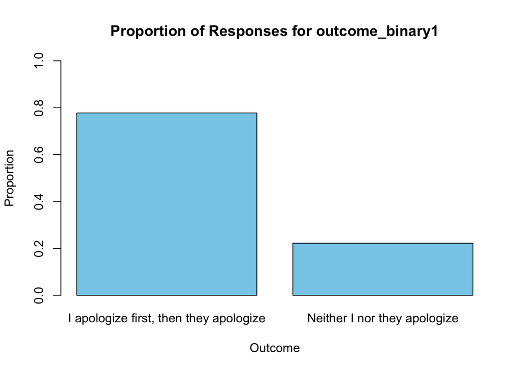

```
##
##  Chi-squared test for given probabilities
##
## data:  table(long_apology_data$outcome_binary1)
## X-squared = 83.333, df = 1, p-value < 2.2e-16
```

There is sufficient evidence to conclude that there is a significant difference between the proportion of people choosing “I apologize first, then they apologize” to outcome_binary1 and the proportion of people choosing “Neither I nor they apologize” to outcome_binary1. This implies that people were much more likely to choose to apologize first followed by an opposing party apology than to choose for neither party to apologize.

## (d) OPTIONAL–This NLP exercise is optional, and primarily relevant to Professors Chaudhry and Kirgios.oNatural Language Processing (NLP) exercise: Find a way to analyze the sentiment and/or emotions present in the free form text responses in the “describe” variable. For instance, you may use packages like VADER, TextAnalyzer, or LIWC (or others). You might even use ChatGPT (in your code; not manually). Describe your observations in a few sentences.

I want to learn how to do this! Right now, I’m not sure how.